# Data Science and Machine Learning with Python

## Contents

- Introduction
- Learning Goals
- Learning material
- Programming platform
- Subjects and Planning
- Subject Description
- Assessment and grading

## Introduction

This course is based on the idea that *learning is doing is learning*.

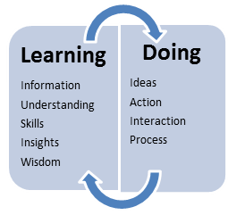

You will make plenty exercises and demonstrate your understanding of your solutions through the notebook format we will be using. Notebooks are a great way to conduct reproducible research and in a sense you will be doing research. You will integrally explain, annotate, and comment on your code in a notebook.

It is commonly known that 70-80% of data research consists of data preparation. You will therefore spend ample time to develop your data preparation skills.

Machine learning is a huge and complex topic. In this course you will scratch the surface of supervised learning, unsupervised learning and some deep learning. But rest assured, after you've finished this course you will have a much better understanding of machine learning than most people merely talking about it.

Your teacher does not qualify as a machine learning expert. Not even near. In fact he is a student and casual user of it himself. You, being 4th year students, however, are expected to be able to learn from other sources than just your teacher. Just as you would not depend too much on a senior colleague after graduation. In fact, being able to train and skill yourself by selecting proper learning sources and setting up your personal training plan, is the single most important quality of a knowledge worker in today's professional world. In this course you will be guided and facilitated to upskill yourself in the field of practical data analysis and machine learning. And rest assured: there are many resources available on the web to learn Machine Learning from. Some of these sources have been mentioned in the additional material list below. There are many, many more learning sources available, depending on your personal interest. Do not forget to put evidence of chasing your personal machine learning interests in your portfolio!

Finally a word of warning. Applying machine learning is only a small part in the process of data mining, or data analysis if you like. There are several process methodologies defining the data mining process. CRISP-DM (cross-industry process for data mining) is probably the most well-known and accepted in industry:

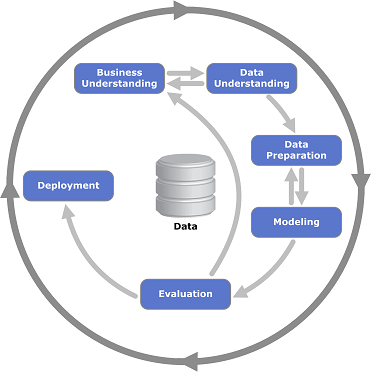

[Here](http://bit.ly/2iK2B3K), you can read a brief introduction to this modeling process.

Be aware that the Data Preparation stage in CRISP-DM entails much more the just importing, tidying and transforming data as defined in the modeling sub process. In a large organization getting data from various enterprise level systems and consolidating and normalizing it in order to be able to start modeling it, can be a very complex and laborious process.

You should always keep in mind that the data mining process entails much more than just modeling the data in order to predict. If you want to successfully apply data mining, or data analysis, you have to spend much time and effort to the organizational embedding of the problem you are trying to solve. This is were the other stages of the CRISP-DM process are all about.

## Learning Goals

From the FT&L's course description:

- Understand, apply and prepare data for well-known machine learning algorithms.
- Evaluate fitness and performance of a machine learning algorithm.
- Conduct evidence based and reproducible data research.

## Learning material

Main learning material:

- [Python Data Science Handbook](http://bit.ly/2xxbgch) - Jake VanderPlas (online book + notebooks)

Endorsed, additional material:

- [A Whirlwind Tour of Python](http://bit.ly/2xx4x2f) - Jake VanderPlas (online book)
- [Markdown for Jupyter notebooks cheatsheet](https://ibm.co/2gsVqIQ)
- [Intro to Python for Data Science](http://bit.ly/2xytuKq) - DataCamp (course)
- [Becoming a Data Scientist](http://bit.ly/2vPjoV0) - DATAQUEST (various python related courses)
- [Whirlwind tour of pandas in 10 minutes](http://bit.ly/2xBbvDq) -Wes McKinney (video)
- [Introduction Into Pandas: Python Tutorial](https://youtu.be/-NR-ynQg0YM) - Daniel Chen (video)
- [Easier data analysis in Python with pandas](http://bit.ly/2wJbbG9) - Data School (video series + notebooks)
- [matplotlib plotting commands](https://matplotlib.org/api/pyplot_summary.html) - matplotlib documentation
- [Data looks better naked](http://bit.ly/2fsaQ0i) - Darkhorse Analytics
- [Machine Learning with Scikit-Learn](https://youtu.be/L7R4HUQ-eQ0) - Jake VanderPlas (video + notebook)
- [Introduction to Machine Learning with Python](https://goo.gl/CuHqRU) - Andres Muller, Sarah Guido
- [scikit-learn: Choosing the right estimator](http://bit.ly/2eziadb) - scikit-learn documentation
- [Introduction to machine learning in Python with scikit-learn](http://bit.ly/2wIcqpc) - Data School (video series + notebooks)
- [Building a Neural Network in Python](http://bit.ly/2xbDVF6) - Jose Portilla
- [Machine Learning Cheat Sheet Mini Site](http://bit.ly/2fASwSG) - Microsoft Azure Machine Learning
- [Data Science for Beginners: The 5 questions data science answers](http://bit.ly/2fLPpHP) Microsoft
- [Useful cheat sheet collection](https://mas-dse.github.io/DSE200/cheat_sheets/)
- [git - the simple guide](http://bit.ly/2vOVPM4) - Roger Dudler
- [Introduction to Principal Component Analysis](http://bit.ly/2ziDKvt)

Interesting articles to broaden your perspective on data science in general and machine learning in particular:

- [Extension of Drew Conway's classic Data Science Venn diagram](http://bit.ly/2gRAsal)
- [Difference between Machine Learning, Data Science, AI, Deep Learning, and Statistics](http://bit.ly/2vK1CTb) - Data Science Central
- [Magic Quadrant for Data Science Platforms](http://bit.ly/2vPopwN) - Gartner
- [Hype Cycle for Emerging Technologies 2017](http://bit.ly/2vK8VKQ) -Gartner
- [How is machine learning used in data science?](http://bit.ly/2vJY5Vb) - Quora
- [New Leader, Trends, and Surprises in Analytics, Data Science, Machine Learning Software Poll](http://bit.ly/2vJRda7) KDnuggets

In addition, tons of material on the subjects covered in this course can be found on the web. Keep in mind that I already did a lot of searching and as a result came up with the list of endorsed material above. I try to stick to these sources (for my own metal well-being). For very specific coding issues, however, StackOverflow will be indispensable.

## Programming platform

We will use Python (Anaconda distribution) as our programming platform.

To get the proper programming environment:

1. install MiniConda
2. install the following additional Python packages:
- NumPy
- Matplotlib
- pandas
- seaborn
- scikit-learn

## Subjects and Planning

| Module | Subject |
| --- | --- |
| 1 | Anaconda; Jupyter Notebook; Python introduction |
| 2 | numpy; Matplotlib |
| 3 | pandas - Data Preparation, Visualization, Time Series |
| 4 | Supervised Learning - Classification (1) |
| 5 | Supervised Learning - Classification (2) (mid-term portfolio assessment) |
| 6 | Supervised Learning - Regression |
| 7 | Unsupervised Learning - Clustering; Dimensionality Reduction |
| 8 | Unsupervised Learning - Self Organizing Maps |
| 9-12 | Final Project |
| 10 | presentation of selected subject and planned results |
| 12 | 5 + 5 minutes result presentation |
| 13 | Assessment |

## Subject Description

### Anaconda, Jupyter Notebook, Python

- The data analysis workflow install Anaconda or Miniconda Python distribution
- idle and IPython
- conda package manager
- Jupyter Notebook
- markdown
- Python introduction
- data types
- control structures
- iteration and comprehension
- functions
- packages

### numpy, Matplotlib

- the case for [NumPy](http://bit.ly/2wBNxvi): efficiency
- size, dimension and indexing (fancy and boolean valued)
- loose the loop: vectorization (ufuncs), aggregation and broadcasting
- data set generation with randomizers
- structure of a Matplotlib plot

### pandas - Data Preparation, Visualization, Time Series

- [pandas](http://bit.ly/2wBsKry) and NumPy
- pandas and R
- pandas and SQL
- indexing
- shape modification: transpose, stack and unstack
- split-apply-combine
- mapping and transforming
- DateTimeIndex
- time grouping
- basic statistics with pandas data
- plotting pandas data

### Supervised Learning - Classification (1)

- Support Vector Machines
- Single Layer Perceptron (neural network)

### Supervised Learning - Regression

- Linear Regression
- Multiple Regression
- Polynomial Regression
- Model Validation (Cross Validation and Accuracy)
- Model Selection (Bias and Variance)

### Unsupervised Learning - Dimensionality Reduction

- Principal Component Analysis

### Unsupervised Learning - Self Organizing Maps

- Self Organizing Maps

### Final Project

- Conduct a data analysis of a problem (with accompanying dataset) of your own interest
- Report on your analysis and reflection in a Jupyter Notebook:
- what is the (business) problem you want to solve or want to learn about?
- how is this problem data related?
- what data do you have at your disposal and what do you want to extract from it?
- for each step in your analysis
  - what are you aiming at with this step?
  - why this approach?
  - how should you interpret the result of your step?
- how does the acquired information (from the data) contribute to solving your original problem?
- Reflect on what you've learned in this project and in the entire course.
- Blend all exercise notebooks and your final report notebook in a portfolio and submit for assessment. Your portfolio is a zipped folder containing all your notebooks.

## Assessment and grading

Each week you will deliver a notebook in which you investigated that week's topic through a set of exercises. Over the last weeks of this course you will be working on a final assignment. Within the boundaries of this course you are free to choose the subject of your final assignment. You are advised to do your final assignment as a couple. If you can't interest any of your classmates to join you in researching a topic of your interest, you are allowed to work alone.

You will present the results of your final assignment to your classmates and possibly other interested persons.

The notebooks of the weekly assignments and your final assignment comprise your portfolio for this subject. Your final assignment will be assessed on soundness of research and reasoning and on depth of analysis.

Your portfolio, timely delivery of the various assignments) and your performance in a brief oral assessment will determine your grade for this subject.